# Fundamentals of Epidemiological Methods

##### 5.4.1.1.2 Cross-sectional studies

A **cross-sectional study** is a type of observational study design in epidemiology where researchers collect data on exposure(s) and outcome(s) at a single point in time, or over a very short period, from a defined population.

This type of study provides a **“snapshot”** of the health status or characteristics of a population, making it useful for assessing the **prevalence** of diseases or conditions.

There are two types of cross-sectional studies

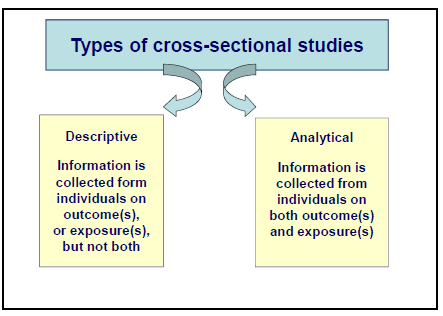

Descriptive cross-sectional studies answers questions like: **What is the prevalence of blindness in the Kenya?**

In desriptive studies, the prevalence of the outcome can be measured without reference to the exposure, for instance;

“the percentage % of JKUAT students suffering from headache on a particular day”

**or** the prevalence of exposure may be measured without reference to the disease or outcome.

“the % persons under 18 years in Nairobi who have used illegal drugs in the past”

These studies are classified as descriptive because the outcome is **not** reported in relation to the exposure or the exposure is **not** reported in relation to the outcome. This can be illustrated by the following diagram;

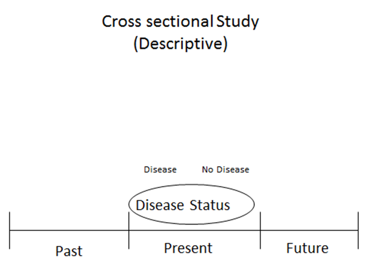

However, if the prevalence of disease is measured in those with and those without he expensive of interest then the study is classified as analytical.

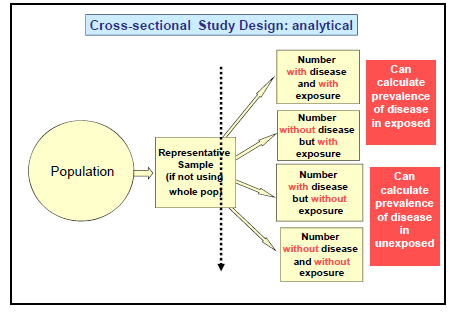

Analytical studies answers questions such as: **What is association between gender and prevalent blindness in the Kenya?**

Cross-sectional studies are relatively simple to conduct and takes only a short time and are relatively cheap. For this reason, they are frequently used for planning purposes. However, they have the major drawback that the can be difficult to interpret as its not possible to know whether the outcome followed the exposure in time or the exposure resulted fro the outcome.

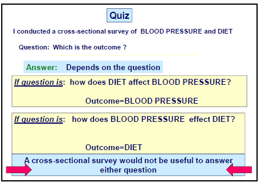

**Key Features of Cross-Sectional Studies**

1. **Single Point in Time**: Data on both the exposure and outcome are collected simultaneously, making it impossible to determine causality. Instead, cross-sectional studies measure the prevalence of an outcome or exposure.
2. **Prevalence Measurement**: Cross-sectional studies are often used to estimate the prevalence of diseases, behaviors, risk factors, or health conditions in a population. This can provide important public health information, such as the percentage of a population that smokes, has diabetes, or is obese.
3. **Population-Based**: Cross-sectional studies can be conducted on entire populations, random samples, or specific subgroups. If the sample is representative, the results can be generalized to a broader population.
4. **Efficiency**: These studies are generally quicker and less expensive than longitudinal studies, as they require only one set of data collection.
5. **Limitation - Temporal Ambiguity**: Since exposure and outcome are measured simultaneously, it’s unclear whether the exposure preceded the outcome or vice versa. This limits the ability to draw causal inferences.

**When to Use Cross-Sectional Studies**

- **Estimating Prevalence**: When the main goal is to determine how common a condition or behavior is within a population.
- **Exploring Associations**: They can reveal potential associations between exposure and outcome, although these are not causative.
- **Public Health Planning**: Useful for identifying risk factors and determining where to allocate public health resources.
- **Generating Hypotheses**: Can be used as a basis for further longitudinal studies that investigate causation.

**Example of a Cross-Sectional Study**

1. **Objective**: Assess the prevalence of hypertension and its association with obesity in a community.

**Method**:

- **Population Selection**: Randomly select a sample of adults from a community.
- **Data Collection**: At a single clinic visit, measure each participant’s blood pressure and body mass index (BMI).
- **Analysis**: Calculate the prevalence of hypertension and obesity. Then, analyze whether hypertension is more common among individuals who are obese.

**Findings**

- Suppose the study finds that 25% of the participants have hypertension and that hypertension is more common among individuals with obesity.

**Interpretation**:

- This cross-sectional study provides data on how common hypertension is in this community and suggests an association between hypertension and obesity. However, since it’s cross-sectional, it cannot prove that obesity causes hypertension.
2. **Schizophrenia** will often result in an inability to hold down a job or may impair the ability of the person to hold a responsible job.

   In this situation cross-sectional studies might show that people with this disease have low economic status. This could be misinteprated as being in a lower social class increases the risk of **Schizophrenia** when in fact the occupational status was determined by the disease.

In reality one would not use cross-sectional study to examine this question because the disease is too uncommon. Meaning, it would be necessary to survey a very large population in order to have sufficient people with the outcome to draw any conclusion. Therefore, cross-sectional surveys are used to estimate the prevalence of common conditions of a reasonably long duration or to determine the distribution of continuous variables within a population.

Here is a good picture illustrating the example above

[figure not shown]

3. A cross-sectional study was conducted among 1,000 factory workers to examine the prevalence of respiratory disease in relation to smoking status. Out of the 1,000 workers:
- 400 are smokers, and among them, 120 have respiratory disease.
- 600 are non-smokers, and among them, 90 have respiratory disease.

  **a. Calculate the prevalence of respiratory disease among smokers.**

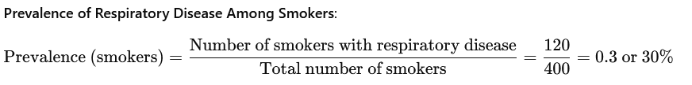

  **b. Calculate the prevalence of respiratory disease among non-smokers.**

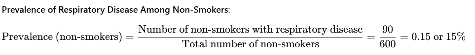

  **c. Calculate the prevalence ratio** to compare the prevalence of respiratory disease between smokers and non-smokers.

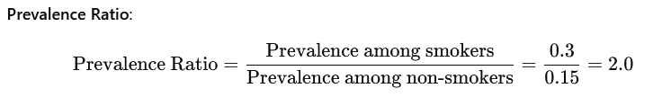

  **d. Interpret the prevalence ratio** in the context of this study.

  The prevalence ratio of 2.0 suggests that the prevalence of respiratory disease among smokers is **twice as high** as it is among non-smokers in this population of factory workers. This indicates a possible association between smoking and respiratory disease, but **causality cannot be determined from a cross-sectional study**.

**Advantages of Cross-Sectional Studies**

- **Quick and Cost-Effective**: Typically easier and less costly than studies requiring multiple follow-ups.
- **Useful for Prevalence Data**: Provides valuable information on the current state of health or risk factors in a population.
- **Good for Multiple Outcomes**: Can simultaneously assess several outcomes and exposures.
- Relatively easy to analyse

**Disadvantages of Cross-Sectional Studies**

- **No Causality**: Temporal ambiguity prevents determination of cause-and-effect relationships.
- **Susceptibility to Bias**: Selection bias and recall bias (if self-reported data is used) can influence results.
- **Cannot Measure Incidence**: Only prevalence is measured, which doesn’t reflect new cases over time.

**Exercise**

A researcher conducts a cross-sectional study to investigate the relationship between physical activity and mental health among university students. The researcher surveys a random sample of students and collects data on the number of hours each student spends on physical activity per week and their mental health status (measured through a validated questionnaire).

1. What type of information can the researcher obtain from this cross-sectional study?
2. What are two advantages of using a cross-sectional study design for this research?
3. Identify two limitations of this study design and explain how these limitations might affect the interpretation of the results.
4. If the study finds an association between higher physical activity and better mental health, can the researcher conclude that physical activity improves mental health? Why or why not?

##### 5.4.1.1.3 Cohort studies

**What is a cohort?**

A cohort is a group of persons (animals) with a common characteristic within defined time period. e.g. people born at the same time, period e.t.c.

Some of the types of cohorts include

- birth cohort
- exposure cohort
- marriage cohort

A **cohort study** therefore is an observational study design in epidemiology where a group of people (or “cohort”) is followed over time to observe how **exposure** to certain factors influences the development of specific **outcomes**.

Cohort studies allow researchers to study the incidence and risk of disease, providing valuable insights into causal relationships between **exposures** and **outcomes**

The starting point of a cohort study is the definition of a group of people by their exposure status. For example, one might take a group of smokers and a group of non-smokers. These are followed up for a period of time to see which ones develop a disease/condition such as **gangrene of the leg or requiring an amputation.**

There are **two** main types of cohort studies. These are

###### 5.4.1.1.3.1 **Prospective cohort study**

- It is a type of cohort study where researchers start with a group of individuals who are free of the outcome of interest and then follow them forward in time to see how certain exposures affect the risk of developing that outcome.
- The following two diagrams illustrate the prospective cohort study design

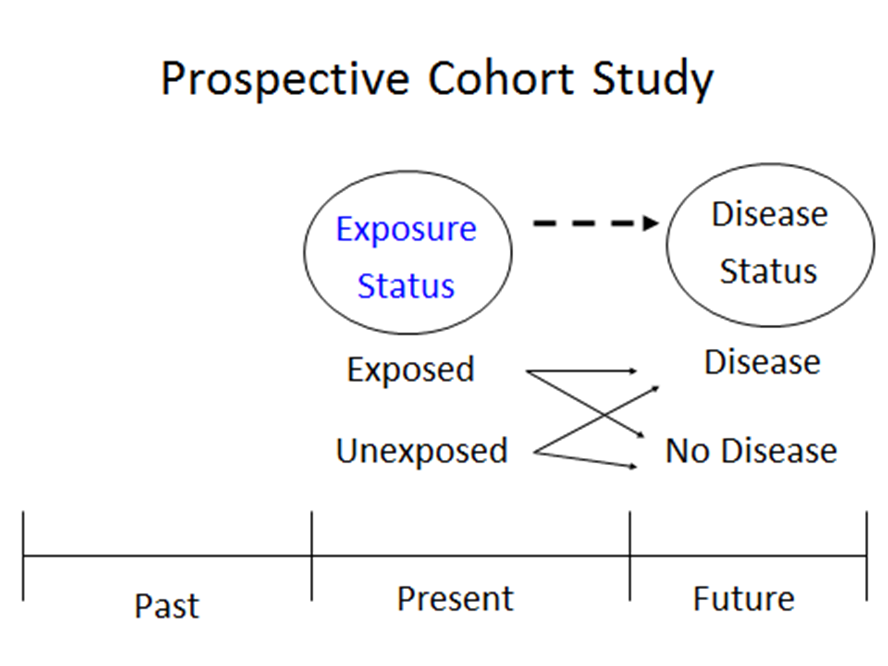

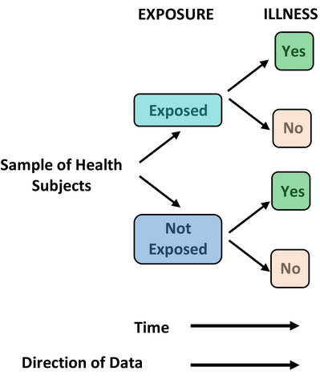

### Key characteristics of prospective cohort studies

  - **Baseline data collection**
    - At the beginning of the study, participants are assessed for various characteristics, including their **exposure status**, demographic information, and potential confounding factors.
    - Exposure information may include lifestyle behaviors (e.g., smoking, diet), environmental factors (e.g., pollution, occupational exposure), or biological markers (e.g., cholesterol levels, blood pressure).
  - **Defined cohort**
    - The cohort consists of individuals who share a specific characteristic or set of characteristics, such as people living in a particular region, workers in a specific industry, or individuals with a similar health status.
    - Participants must be free of the outcome of interest (e.g., disease) at the beginning of the study to ensure that exposure precedes the outcome.
  - **Follow-up period**
    - The cohort is followed over a specified period, **often years or even decades**, to monitor the occurrence of new cases of the outcome. This period can vary based on the study’s objective and the anticipated time it might take for the outcome to develop. This is based on prior knowledge of the natural history of the disease
    - During follow-up, researchers collect updated **exposure** information and monitor for the outcome of interest, such as the incidence of a disease or health event. If the disease (e.g. tuberculosis) over time develops more frequently amongst the exposed group (e.g. living in an over-crowded house) than amongst the unexposed group (don’t live in an over-crowded house) then the exposure might be causing the disease. The proportion of people who develop the disease over time is referred to as the *incidence* of disease
  - **Outcome assessment**
    - Throughout or at the end of the follow-up period, researchers assess the incidence of the outcome (e.g., development of disease, death) among participants.
    - This can involve periodic health assessments, medical record reviews, or self-reported surveys, depending on the outcome and the study’s design.
  - **Temporal Sequence**:
    - Because exposure is measured before the outcome occurs, prospective cohort studies provide a clear timeline that supports causal inferences.
- This study design is particularly valuable in epidemiology for establishing a **temporal** sequence between an **exposure** and an **outcome**, which is essential for assessing **causation**.

### 5.4.2 Advantages of prospective cohort studies

- **Establishing temporal relationship**: Since exposure data is collected before the outcome, it’s easier to infer a causal link between the exposure and the outcome.
- **Minimizing recall bias**: Exposure information is collected in real-time (at baseline), so it does not rely on participants’ memory of past exposures, reducing recall bias.
- **Multiple outcomes**: Prospective cohort studies can assess the impact of a single exposure on multiple outcomes. For example, a study on smoking could examine not only lung cancer but also heart disease and stroke.
- **Measurement of incidence**: This design enables the calculation of the incidence (new cases) of the outcome in both exposed and unexposed groups, allowing for the estimation of relative risk (RR).
- Ideal for studying rare exposures

### 5.4.3 Disadvantages of prospective cohort studies

- **Time and cost-intensive**: Because of the need for extended follow-up and regular data collection, prospective cohort studies are resource-intensive and often costly.
- **Loss to follow-up**: Over time, some participants may drop out due to relocation, loss of interest, or death, which can introduce bias if the dropout is related to exposure or outcome.
- **Not ideal for rare outcomes**: If the outcome of interest is rare, the study may require a very large sample size to capture enough cases, making it logistically challenging and costly.
- **Potential for confounding**: Even with careful study design, prospective cohort studies may be affected by confounding variables, which are other factors that might affect the outcome.

**Example**

**Study Objective**: To examine the relationship between physical activity and cardiovascular disease (CVD) in adults.

**Study Design**:

1. **Baseline recruitment**: Researchers enroll 5,000 adults aged 40-60 years who are free of CVD. Participants complete a baseline survey on their physical activity levels and other factors such as diet, smoking status, and medical history.
2. **Follow-up**: Researchers follow participants for 10 years, during which time they periodically assess physical activity levels and monitor participants for any new diagnoses of CVD, such as heart attack or stroke.
3. **Outcome measurement**: Incidence of CVD is tracked through regular medical check-ups and review of medical records.
4. **Data analysis**: The incidence of CVD in high-activity participants is compared to that in low-activity participants to determine if higher physical activity levels are associated with a reduced risk of CVD.

**Findings**:

- Suppose the study finds that participants with higher physical activity levels have a significantly lower incidence of CVD compared to those with lower activity levels.

**Interpretation**:

- This finding suggests a possible protective effect of physical activity against CVD. Because the study is prospective, with exposure measured before the outcome, there is stronger evidence to support a causal relationship.

### 5.4.4 Key Measures in Prospective Cohort Studies

1. **Incidence rate**: The rate at which new cases of the outcome occur in a population over time.

   ${\text{Incidence Rate(IR)}} = \frac{\text{Number of new cases}}{\text{Person-time at risk}}$
2. **Relative Risk (RR)**: A measure that compares the risk of the outcome in the exposed group to the risk in the unexposed group.

   $\text{Relative Risk (RR)} = \frac{\text{Incidence in exposed group}}{\text{Incidence in unexposed group}}$
3. **Attributable Risk (AR)**: The difference in incidence between exposed and unexposed groups, representing the incidence of disease that could potentially be prevented if the exposure were eliminated.

   $\text{Attributable Risk (AR)} = \text{Incidence in exposed} - \text{Incidence in unexposed}$

**In summary**

- **Prospective cohort** studies are a gold standard for studying the effects of risk factors on the development of disease over time.
- They provide essential data on incidence, enable the study of multiple outcomes from a single exposure, and support a temporal sequence between exposure and outcome. However, they require significant resources and are susceptible to biases from loss to follow-up and confounding.
- Despite these challenges, prospective cohort studies are among the most powerful observational designs for exploring causality in epidemiology.

The **key features** of cohort studies include;

- **Longitudinal Follow-Up**: Cohort studies are designed to observe participants over a specified period, which may be *months, years, or even decades*. They measure the incidence (new cases) of a disease or outcome over time.
- **Exposed vs. Unexposed Groups**: A cohort study typically starts by identifying two groups within the cohort: those who have been exposed to a risk factor or intervention (e.g., smokers) and those who have not (e.g., non-smokers). The study then tracks outcomes in both groups to assess any association with the exposure.
- **Prospective vs. Retrospective Cohort Studies**
  - **Prospective Cohort Study**: Enrolls participants and follows them into the future. Data on exposure and other variables are collected at the start and monitored over time.
  - **Retrospective Cohort Study**: Uses past records to determine participants’ exposure status and follows them up to the present to assess outcomes. It’s faster and less expensive than prospective studies but relies on the availability and accuracy of historical data.
- **Temporal Relationship**: Since exposure is measured before the outcome occurs, cohort studies can establish a temporal sequence, which strengthens causal inferences.

Design steps

identify one or more groups of individuals who share some common attribute (the ‘cohort’) • classify cohort members according to the key exposure(s) of interest • follow-up cohort members to determine disease occurrence • relate information on disease occurrence to exposure

strengths

They can be used to study relatively **rare exposures**

1. They can be used to study a **wide range of disease outcomes**
2. Information on **exposure** relates to time period **before disease onset**
3. Detailed information on **confounding factors** can be collected
4. Detailed data on exposure permits opportunity to study **‘dose-response’ relationships**

   Weaknesses
5. Study size
6. Cost of data collection
7. Time required to conduct the study — and losses to follow-up Because of the strengths and weaknesses, cohort studies are most often used when the disease of interest is common and/or the effects of the exposure are nonspecific or not well-defined

Analysis

a. Comparison of disease rates in cohort with rates in general population

b. Compare disease risk (or rate) in exposed cohort members with unexposed cohort members

Comparison of cohort groups

RR, RR, OR

##### 5.4.4.0.1 A pictorial illustration of the study designs considered

Cross-sectional

Cohort

Case-Control

Experimental

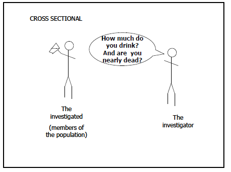

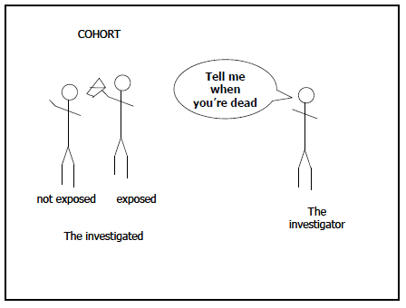

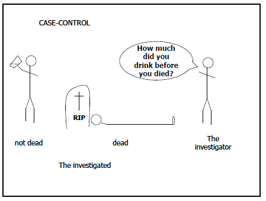

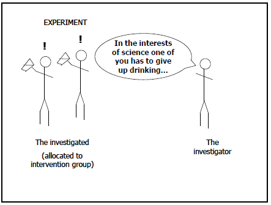

# 6 Interpretation of Epidemiological Studies

# 7 **Useful links / Recommended books**

While preparing these notes, I have benefited from various authors and would like to share some of the details as follows

- Epidemiology: An introduction - *Open University course K311 Promoting public health:* http://www3.open.ac.uk/study/undergraduate/course/k311.htm
- History of epidemiology https://bio.libretexts.org/Bookshelves/Microbiology/Microbiology_(Boundless)

  /10%3A_Epidemiology/10.01%3A_Principles_of_Epidemiology/10.1A%3A_History_of_Epidemiology
- **Lecture Notes:** For Environmental and Occupational Health Students (Epidemiology) - *Ethiopia Public Health Training Initiative, University of Gondar*
- Understanding the Fundamentals of Epidemiology an evolving text, *Victor J. Schoenbach, Ph.D. & Wayne D. Rosamond, Ph.D*.
- Principles of Epidemiology in Public Health Practice -An Introduction to Applied Epidemiology and Biostatistics - *Self Study (CDC)* : https://www.cdc.gov/csels/dsepd/ss1978/index.html
- Understanding the Epidemiologic Triangle through Infectious Disease https://www.cdc.gov/healthyschools/bam/teachers/documents/epi_1_triangle.pdf
- Outbreak toolkit https://outbreaktools.ca/background/descriptive-epidemiology/
- What Is the Epidemiologic Triangle? https://www.rivier.edu/academics/blog-posts/what-is-the-epidemiologic-triangle/
[^1]: **Aflatoxins are a family of toxins produced by certain fungi that are found on agricultural crops such as maize (corn), peanuts, cottonseed, and tree nuts**
[^2]: Durkheim, E. (1897). Le suicide. Paris: F. Alcan. English translation by J A Spalding (1951). Toronto, Canada: Free Press/Collier-MacMillan.